# Ford Go Bike System Data Analysis

## By Marzuk Sulemana

## Investigation Overview

The main feature I was interested in was the duration of members and how it was dependent on other features of the data.I focused on the dependency of duration on the age of the users, the user types (subscribers or customers)and member gender (male, female, other).

## Dataset Overview

The data contains *183412* rows and *16* columns. Some of the columns in this data include *duration_sec*, *start_station_id*, *start_station_latitude*, *start_station_longitude*, *end_station_id*, *end_station_latitude*, *end_station_longitude*, *bike_id*, *member_birth_year* etc. All rows with null values were romoved from the data.

## Distribution of Duration in minutes

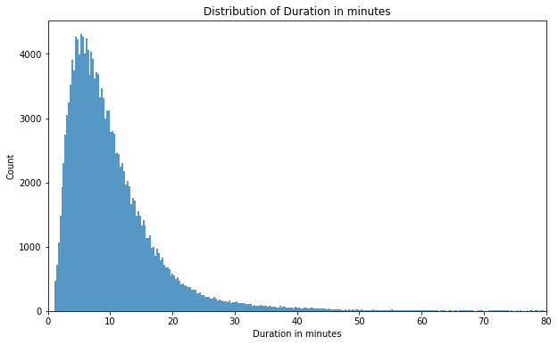

## Duration vs Age

We can see that bike duration seem to be dependent on age of users where increase in user age leads to decrease in bike duration. Most of the duration lie below *200 minutes* and users having bike durations above *200 minutes* have their ages between *19 and 72 years*.

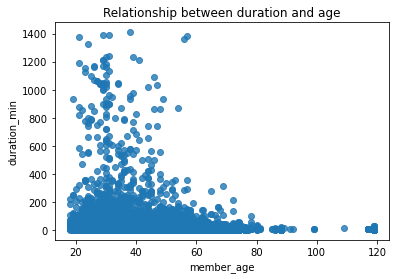

## Duration vs. Gender

The relationship between duration and gender showed that only members in the other gender have their mean duration more than *15 minutes*. Members who are females have mean duration of *12.98 minutes* whiles members who are males have mean duration of *11.2 minutes*.

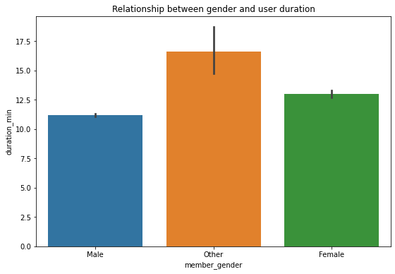

## Duration vs. User type

There are more subscribers than customers in the system. Even so, users who are customers turn to have high mean duration (*21.84 minutes*) than subscribers (*10.68 minutes*). This might imply that when users subscribe to the bikeshare system, it does not mean that they plan to have longer bike durations.

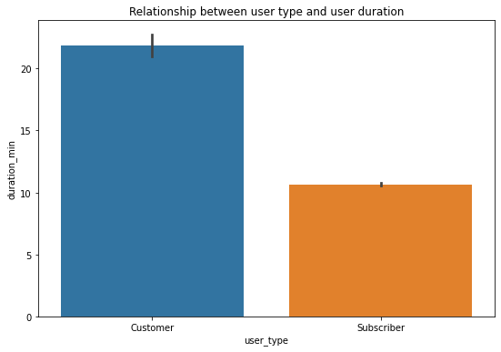

## Duration by member age and gender

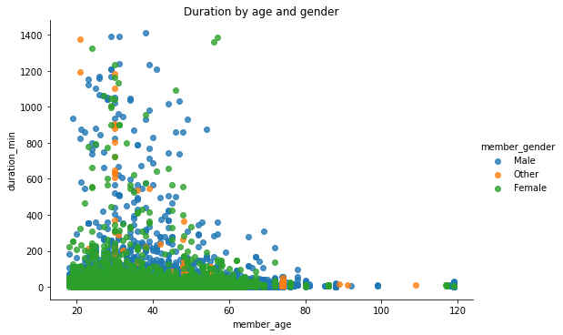

## Member age vs. Gender

There is a close relationship between the mean ages of males, females and other gender, they all have their mean ages between *33 and 36 years*.

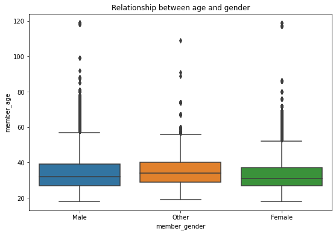

## Conclusion

From the data exploraton, we have seen that bike duration is dependent on age where increase in user age leads to decrease in bike duration. We have also observed that even though there are more subscribers than customers in the system, Users who are customers turn to have longer bike duration than subscribers. Therefore, we might say that when users subscribe to the bikeshare system, it does not mean that they will have longer duration. Also, despite other gender being the least members in terms of population, they actually have longer bike duration than males and females.